# How Can a Wellness Technology Company Play It Smart?

## Bellabeat Case Study

[figure not shown]

### **Introduction**

Founded in 2013,Bellabeat- a high-tech company that manufactures health-focused smart products, has grown rapidly and quickly positioned itself as a tech-driven wellness company for women. Collecting data on activity, sleep, stress, and reproductive health has allowed Bellabeat to empower women with knowledge about their own health and habits.

Already by 2016 the company has spread worldwide, opening offices around the world and lunching multiple products. Their reach to customer comes through a growing number of online retailers in addition to their own e-commerce channel on [their website](https://bellabeat.com/).

To keep up with the competitive environment and evolve the company to the next level an analysis of Bellabeat’s available consumer data has been proposed. The goal is to gain insight into how people are already using their smart devices. Thus by providing high-level recommendations a marketing strategy can be made.

The base of the data analysis will be built upon collected user information of Fitbit devices. [Fitbit](https://www.fitbit.com/global/dk/home) is an American consumer electronics and fitness company. It produces wireless-enabled wearable technology, physical fitness monitors and activity trackers such as smartwatches, pedometers and monitors for heart rate, quality of sleep and stairs climbed as well as related software.

In 2019, Fitbit was the fifth largest wearable technology company in shipments. The company has sold more than 120 million devices and has 29 million users in over 100 countries.

#### **Key Stakeholders:**

Urška Sršen, Bellabeat’s co-founder and Chief Creative Officer Sando Mur, Bellabeat’s co-founder and Mathematician Marketing analytics team

#### **Questions for the analysis**

1. What are some trends in smart device usage?
2. How could these trends apply to Bellabeat customers?
3. How could these trends help influence Bellabeat marketing strategy?

#### **Business task**

Analyze smart device data to gain insight into how consumers are using their smart devices to help to guide the marketing strategy for the company. Deliver data analysis to the Bellabeat executive team along with your high-level recommendations for Bellabeat’s marketing strategy.

#### **Data**

The **reliability** of data is valued as low as the sample size is quite small, and no additional information about participants’ gender, lifestyle, demographic and time location is provided. Additionally time period of measurement only lasts a month between April and May The **originality** of the data is also valued as low as data is sourced from a third-party survey by Amazon Mechanical Turk. The **comprehensiveness** can be valued as medium as Fitbit’s measured parameters match with some of the Bellabeats’s(activity,sleep). The **current** can be valued as low as data was collected in 2016 which is 7 years ago. The **citation** is also valued as low as data comes from third party generated by respondents to a distributed survey via Amazon Mechanical Turk between 03.12.2016-05.12.2016.

### **Environment set up**

First step before starting with any data cleaning and analysis is to load the necessary packages that will help with execution of the code. Used packages in this case are: *Tidyverse, dplyr, lubridate, ggplot2, tidyr, readr, calendarR, ragg, openair*.

Important step after installing the packages include looking them up with library function, it both helps with making sure they are loaded and helps with starting them up.

```r
library(tidyverse)
library(lubridate)
library(dplyr)
library(ggplot2)
library(tidyr)
library(readr)
library(calendR)
library(ragg)
library(openair)
```

Next step involves uploading the necessary data files, original data set contains 18 smaller data sets, in this case only 7 of them will be used: Daily Activity, Daily Calories, Daily Intensity, Daily Steps, Daily Sleep, Weight Loss and Hourly Steps.

```r
daily_activity <- read.csv("dailyActivity_merged.csv")
daily_calories <- read.csv("dailyCalories_merged.csv")
daily_intensity <- read.csv("dailyIntensities_merged.csv")
daily_steps <- read.csv("dailySteps_merged.csv")
daily_sleep <- read.csv("sleepDay_merged.csv")
weight_loss <- read.csv("weightLogInfo_merged.csv")
hourly_steps <- read.csv("hourlySteps_merged.csv")
```

### **Data cleaning**

First, to get an idea about the look of the data a header() function can be used to retrieve first six entries in the table also including column names. This should be done to all of the files in order to know what information in stored and what formatting is used.

```r
#Getting overview of data
head(daily_activity)
head(daily_calories)
head(daily_intensity)
head(daily_sleep)
head(daily_steps)
head(weight_loss)
head(hourly_steps)
```

It can be observed that all of the data sets contain unique Id numbers for the participants and date when the measurement is made, this will allow us in future to combine separate data sets based on these conditions.

To continue with the analysis, an important part is data cleaning and adjusting, to make sure that formatting, data type, date are the same across the data. This will allow to combine and merge the data sets without problems. In this case minimal data manipulations were necessary, mostly including renaming columns, changing date format, and excluding some columns from data frames.

```r
#Activity table

activity <- daily_activity %>%
  rename(Date = ActivityDate) %>%
  rename(Steps = TotalSteps) %>%
  rename(Distance = TotalDistance)%>%
  select(-c(10))
activity$Date=as.POSIXct(activity$Date, format="%m/%d/%Y", tz=Sys.timezone())

#Calories table
calories <- daily_calories %>%
  rename(Date = ActivityDay)

calories$Date=as.POSIXct(calories$Date, format="%m/%d/%Y", tz=Sys.timezone())

#Intensity table
intensity <- daily_intensity %>%
  rename(Date = ActivityDay) %>%
  select(c(1:6))

intensity$Date=as.POSIXct(intensity$Date, format="%m/%d/%Y", tz=Sys.timezone())

#Sleep table
sleep <- daily_sleep %>%
  rename(Date = SleepDay) %>%
  separate(col = Date, into = c("Date", "Datetime"), sep = " ") %>%
  select(-c(3))

sleep$Date=as.POSIXct(sleep$Date, format="%m/%d/%Y", tz=Sys.timezone())

#Steps table
steps <- daily_steps %>%
  rename(Date = ActivityDay) %>%
  rename(TotalSteps = StepTotal)

steps$Date=as.POSIXct(steps$Date, format="%m/%d/%Y", tz=Sys.timezone())

#Steps by hour table
hsteps <- hourly_steps %>%
  extract(ActivityHour, into = c("Date", "time"), "^(\\S+)\\s+(.*)")

hsteps$time <- parse_time(hsteps$time, '%H:%M:%S %p')

 #Weight table
 weight <- weight_loss %>%
  separate(col = Date, into = c("Date", "Datetime"), sep = " ") %>%
   select(-c(3,7,8))

weight$Date=as.POSIXct(weight$Date, format="%m/%d/%Y", tz=Sys.timezone())
```

In the next step a fast data check can be done by counting unique id’s in each data set. As mentioned before there are 33 participants in this case study that shared their fitness tracker data.

```r
#Exploring unique participants in each section
n_distinct(activity$Id)
n_distinct(calories$Id)
n_distinct(intensity$Id)
n_distinct(steps$Id)
n_distinct(sleep$Id)
n_distinct(weight$Id)
```

The output as continues:

33;33;33;33;24;8

Based on this information weight data will be excluded from the analysis as 8 participants can not be considered feasible sample amount, in order to see any trends and patterns.

### **Data analysis**

In order to provide insights of how customers are using their smart devices to help the Bellabeat with marketing strategy, some scoping down of the data will be necessary. As Bellabeats Leaf and Time devices both track only activity, sleep and stress. This will serve as a good indication to only focus on activity and sleep data sets collected from the Fitbit users.

Based on the information collected, the sleep data set contained 24 unique id’s and activity data set 33 unique id’s. Thus as a base for merged data set the daily sleep data set will be taken and paired with daily steps.This way we are ensuring that all of the id’s have both sleep and steps data.

```r
#Joining activity and sleep data sets
merged_data <- merge(activity,sleep, by=c('Id', 'Date'))%>%
  rename(date = Date)
head(merged_data)
```

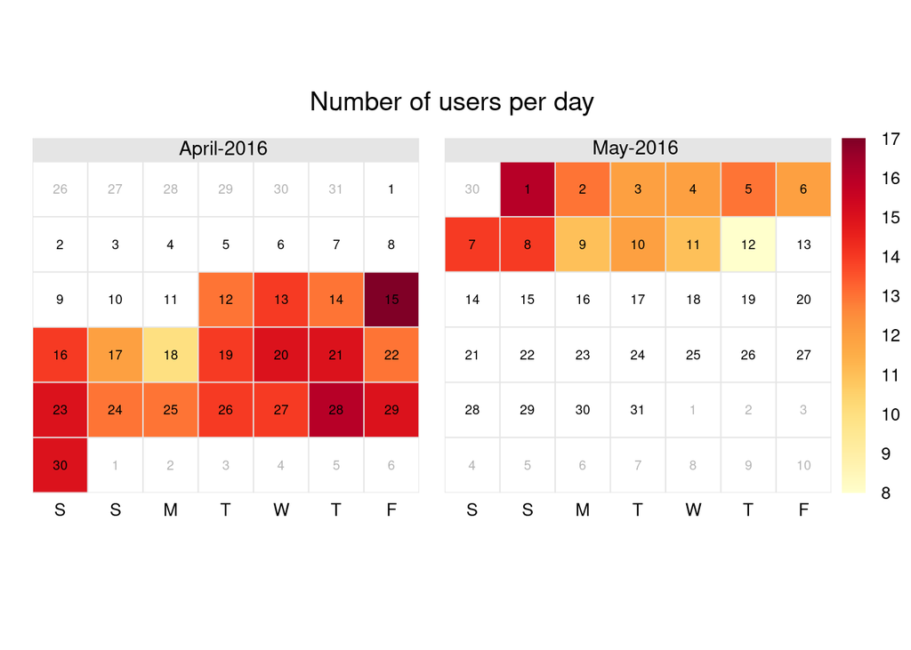

```r
# Getting number of users for each day
activity_df <- merged_data %>% group_by(date) %>%
  summarise(uniqueid = sum(n()), .groups = "drop")

#Making calendar plot
calendarPlot(activity_df, pollutant = "uniqueid", month = 4:5, main =  "Number of users per day" )
```

Getting summary of data:

```r
summary(activity_df$uniqueid)
```

```
##    Min. 1st Qu.  Median    Mean 3rd Qu.    Max.
##    8.00   12.00   13.00   13.32   14.50   17.00
```

Range of data goes from 8 users per day, with mean of 13 users and max of 17 users. No days have recorded all of the 24 users. Slight decline can be seen in the usage compared from the beginning to the end of the period.

For a closer look of the data to understand customer usage of the smart devices the monthly time cut can be reduced to a week, visualizing average steps taken in each day.

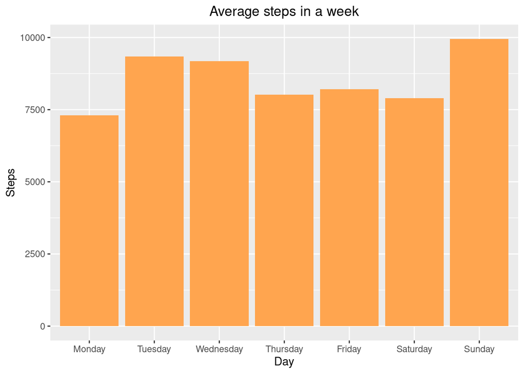

```r
#Plotting average steps by day in a week, to see trends
#Making a new column in df to assign a day of week for each date
 daysteps <- merged_data
 merged_data$weekday <- c("Monday", "Tuesday",
                    "Wednesday", "Thursday", "Friday",
                    "Saturday","Sunday")[as.POSIXlt(merged_data$date)$wday + 1]

 merged_data$weekday <- factor(merged_data$weekday, levels = c("Monday", "Tuesday", "Wednesday", "Thursday", "Friday", "Saturday", "Sunday"))

ggplot(merged_data, aes(x = weekday, y = Steps, fill = weekday)) +
   geom_bar(aes(fill = Steps), stat = "summary", fun = "mean", fill = "tan1")+
  labs(title = "Average steps in a week", x = "Day")+
  theme(plot.title = element_text(hjust = 0.5))
```

Furthermore it can also be looked at average steps in a day taken each hour.

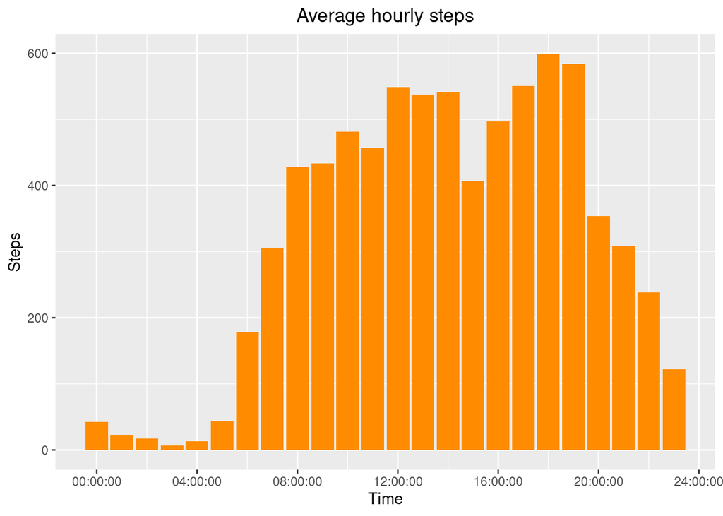

```r
#Plotting hourly steps in average, to see any trends

 ggplot(hsteps, aes(x = time, y = StepTotal)) +
   geom_bar(stat = "summary", fun = "mean", fill = "darkorange")+
   labs(title = "Average hourly steps", x = "Time", y = "Steps")+
   theme(plot.title = element_text(hjust = 0.5))
```

As expected a slight peek can be observed in hours after 16:00, when most of people finish the workday. Surprisingly relatively high number of steps are also walked in hours from 8:00 to 16:00, witch indicates active work environment (assuming participants work full-time).

For additional information lets look at frequency of total steps walked in a day over the time period showed in a histogram.

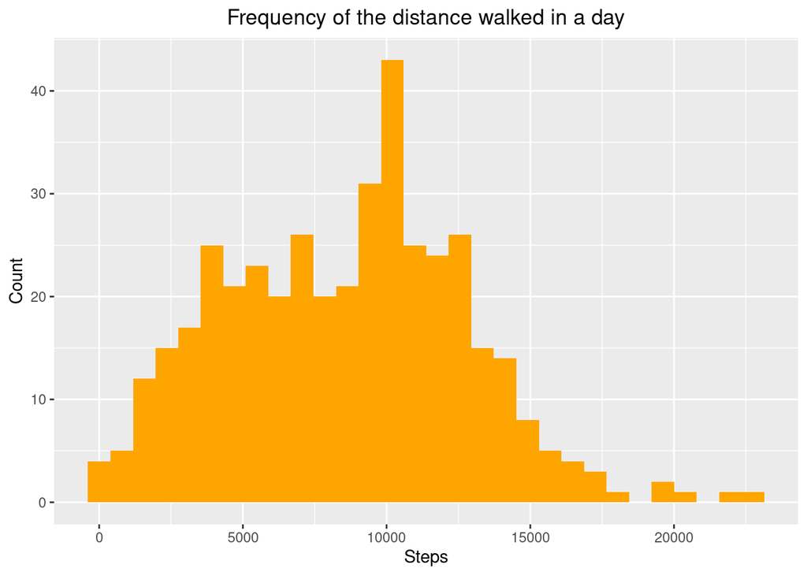

```r
 ggplot(data = merged_data)+
   geom_histogram(mapping = aes(x = Steps), fill = "orange")+
   labs(title = "Frequency of the distance walked in a day", y = "Count")+
   theme(plot.title = element_text(hjust = 0.5))
```

Getting also a summary :

```r
 summary(merged_data$Steps)
```

```
##    Min. 1st Qu.  Median    Mean 3rd Qu.    Max.
##      17    5206    8925    8541   11393   22770
```

According to some experts steps and activity levels can be divided into four levels: sedentary is less than 5,000 steps per day , low active is 5,000 to 7,499 steps per day. Somewhat active is 7,500 to 9,999 steps per day. Active is more than 10,000 steps per day. Highly active is more than 12,500. From our data the average steps taken are 8541 witch qualifies as somewhat active lifestyle.

### **Summary and recommendations**

Key points:

#### **Customization**

Suggestion to introduce more options for setting preferences for targets/goals for sleep and steps in Bellabeat app. Possibility to have reminders in specific time frames for increasing activity, for example after work or reminders when sedentary period runs for a long time. Even weekly and monthly challenges can be introduced.This way user engagement may increase and increase added value of the product.

#### **Comfort**

From the sample data it is seen that sleep data was recorded only for 24 participants. One of the possible cause could be the device comfort level during the sleep. In Bellabeat’s case Leaf product when worn as a necklace could limit accuracy of the sleep data. In order to understand if chose of device impacts the measurement accuracy more data from Bellabeat consumers should be collected.

#### **Features**

Suggestion to expand and introduce new features in Bellabeat app, for example calorie intake that would interact with activity level to show calorie expenditure, to further guide user towards their goal. Hand in hand to this weight feature would also tie together to activity and calorie features. With the new feature also new products can be introduces as smart-scale and health-food cookbook.

Some positive effects of tracking your weight and calories should be presented to boost the possibility of user interest of such functions.